# Final Project Bayesian Data

Gonzalo Tomás

4/25/2021

#### Degree in Data Science and Engineering, Uc3m.

#### Gonzalo Tomás Garcinuño

In this project, I will solve a couple of problems following the guidelines we saw in class. The data used is obtained from this [link.](https://blogs.oregonstate.edu/bida/data-sets-and-code/) In particular, I will be using the dataset called *FullFEVdataExercise9-21.txt*.

This lab consists of two parts:

In the first part, we will be covering **Bayesian Prediction**.

In the second one, **Generalized Linear Models** will be used.

### Load the data

First, the data will be loaded

```r
setwd("~/Documents/University/Uni/CARLOS III/3-Tercero/Segundo cuatri/Bayesian Data/Final Project")

rm(list=ls())
data <- read.table('FullFEVdataExercise9-21.txt', header = TRUE)
head(data)
```

```
##     Id Age   FEV  Hgt Male Smoke
## 1  301   9 1.708 57.0    0     0
## 2  451   8 1.724 67.5    0     0
## 3  501   7 1.720 54.5    0     0
## 4  642   9 1.558 53.0    1     0
## 5  901   9 1.895 57.0    1     0
## 6 1701   8 2.336 61.0    0     0
```

```r
attach(data)
```

# Part1: Bayesian Prediction

In this part of the project, we will assume the FEV variable follows a normal distribution.

$$X∣μ,τ∼ Normal\left(μ,\frac{1}{τ}\right)$$

We will also assume the conjugate prior distribution for the normal distribution

We will assume the conjugate prior distribution for the normal distribution, that is, a normal-gamma prior distribution:

$$μ∣τ∼Normal \left(m,\frac{1}{cτ}\right)$$

$$τ∼Gamma \left( \frac{a}{2}, \frac{b}{2} \right)$$

### Plots and Introduction

We will visualize the variable we will be trying to predict, *FEV*

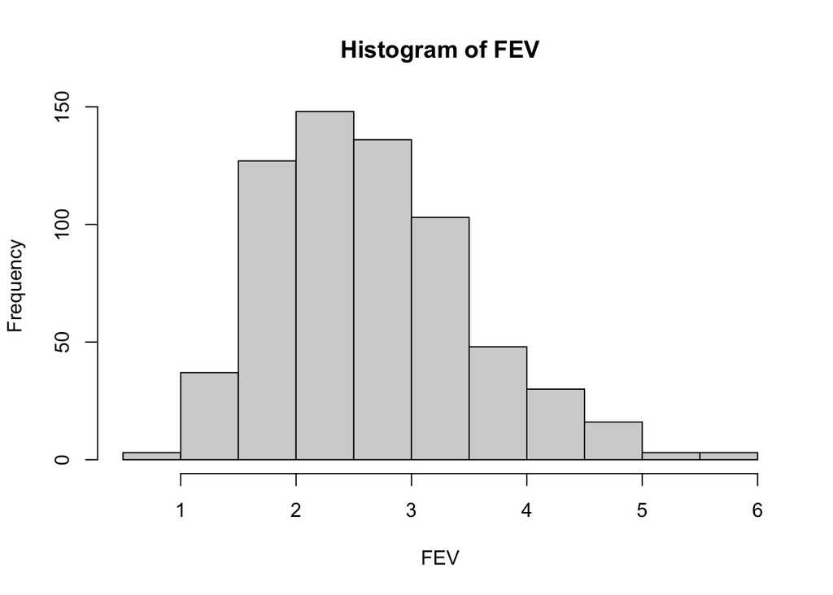

```
##      mean        sd   min   max
## 1 2.63678 0.8670591 0.791 5.793
```

### Bayesian Normal Model

We will initialize the prior model parameters.

$$c^* = c + n$$

$$a^* = a + n$$
$$b^* = b+(n−1)s^2 + \frac{cn}{c+n}(m-\overline{x})^2$$
But first, we assume *non-informative* priors

```r
m=0; c=0.05; a=0.05; b=0.05

n <- length(FEV)
mean.fev <- mean(FEV)
var.fev <- var(FEV)

m.star = (c*m+n*mean.fev)/(c+n)
c.star = c+n
a.star = a+n
b.star = b+(n-1)*var.fev+c*n*(m-mean.fev)^2/(c+n)
```

We will, perform some analysis and create a plot of the prior and posterior joint distribution parameters.

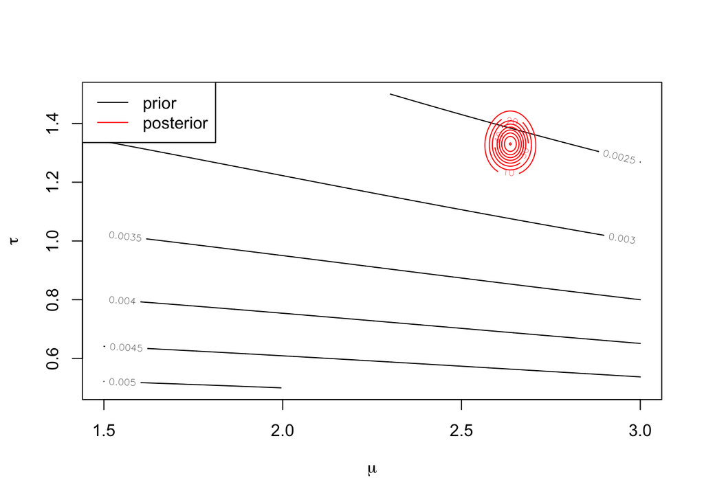

```r
library(nclbayes)

plot.joint <- function(mu, tau){
  NGacontour(mu,tau,m,c,a,b)
  NGacontour(mu,tau,m.star, c.star, a.star, b.star, add=TRUE,col="red")
  legend("topleft",c("prior","posterior"),lty=c(1, 1),col=c("black","red"))
}

mu <- seq(1.5,3,len=1000)
tau <- seq(0.5,1.5,len=1000)
plot.joint(mu, tau)
```

We will use Monte Carlo sampling to estimate the joint distribution of the data:

(These are just the formulas we introduced before, but with the variables updated to their corresponding values)

Using **Monte Carlo sampling**, we may obtain a sample of size (M = 15.000) from this joint distribution using:

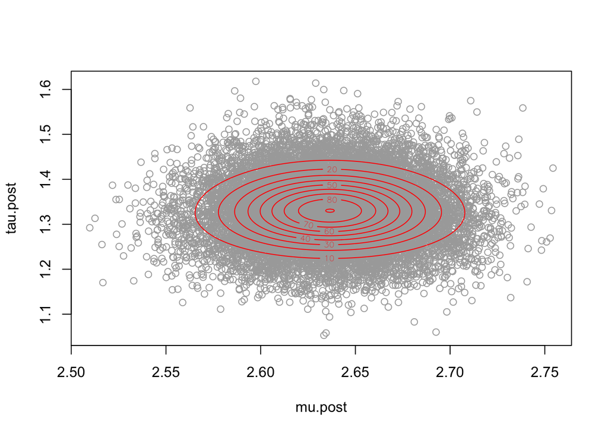

```r
plot.monte.carlo <- function(mu.post, tau.post, mu, tau){
  plot(mu.post, tau.post, col="darkgrey")
  NGacontour(mu, tau, m.star, c.star, a.star, b.star, col="red",add=T)

}

M <- 15000
tau.post <- rgamma(M,shape=a.star/2,rate=b.star/2)
mu.post <- rnorm(M,mean=m.star,sd=sqrt(1/(c.star*tau.post)))
plot.monte.carlo(mu.post, tau.post, mu, tau)
```

The Credible Intervals for $μ$ and $τ$ can be calculated like so:

```r
# credible interval for mu
quantile(mu.post,c(0.025,0.975))
```

```
##    2.5%   97.5%
## 2.57105 2.70296
```

```r
# credible interval for tau
quantile(tau.post,c(0.025,0.975))
```

```
##     2.5%    97.5%
## 1.191289 1.477744
```

Now, the **Predictive Probabilities** of the sample will be calculated.

The predictive density can be obtained by using the following formula:

$$f(xn+1∣data)=∫f(x∣μ,τ)f(μ,τ∣data)dμdτ$$

If we assume a normal-gamma prior for $(μ,τ)$, we obtain the predictive distribution for **FEV**

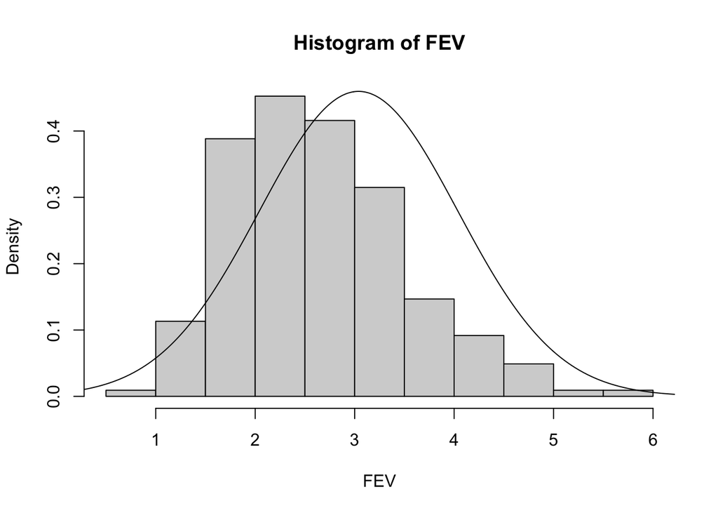

```r
hist(FEV, freq=F)
x.axis <- seq(0, 7, by=0.01)
pred.mean <- m.star
scale=(c.star+1)*b.star/(c.star*a.star)
lines(x.axis,dt(x.axis-pred.mean/sqrt(scale), a.star)/sqrt(scale))
```

This is the comparison of the *empirical cdf* with the *predictive cdf*. We can see that we get a decent result, although not ideal.

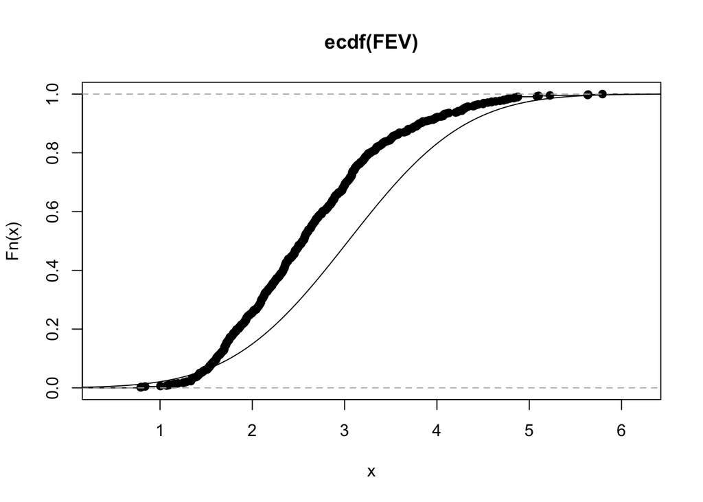

```r
plot(ecdf(FEV))
lines(x.axis, pt(x.axis - pred.mean / sqrt(scale), a.star))
```

```r
val.to.estimate <- 2.4
1-pt((val.to.estimate - pred.mean)/sqrt(scale),a.star)
```

```
## [1] 0.6074349
```

# Part2: Generalized Linear Models

Here, we will try to predict whether a person Smokes or not. We will be working with the same data as before.

The first step is to visualize the data.

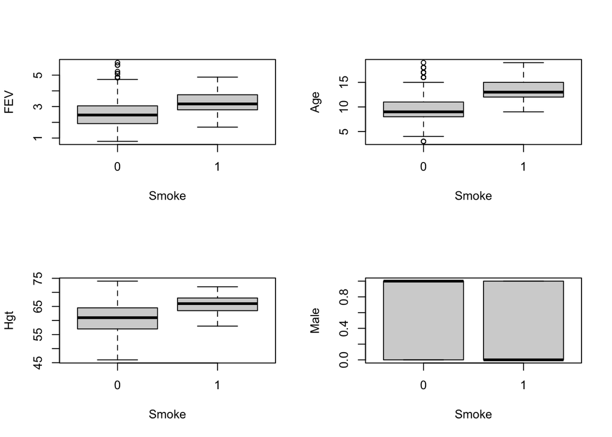

```r
par(mfrow = c(2, 2))
boxplot(FEV ~ Smoke)
boxplot(Age ~ Smoke)
boxplot(Hgt ~ Smoke)
boxplot(Male ~ Smoke)
```

We will look at the plots among the variables, to see how they interact with each other. And try to see linearity among the variables.

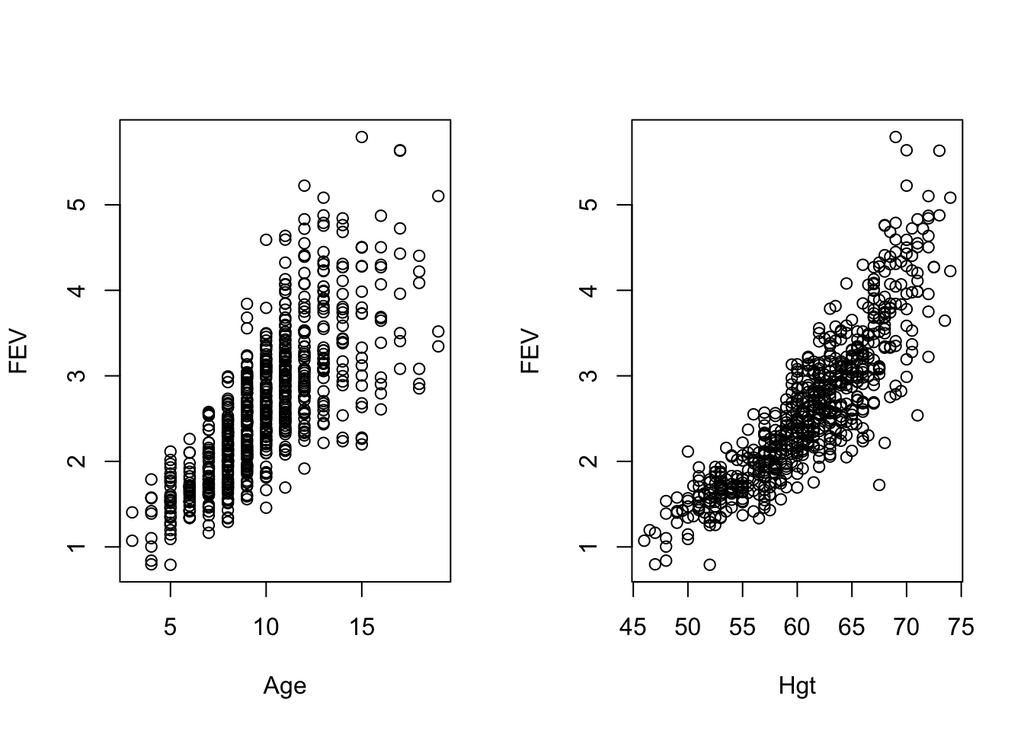

```r
par(mfrow = c(1, 2))
plot(Age, FEV)
plot(Hgt, FEV)
```

We can see that there seems to be positive linear correlation among these variables. This might indicate the the higher the **Age**, the higher the **Volume** in the lungs. The same applies for **Height**; someone who is bigger in size will for sure be able to exhale more oxygen than a smaller person. (This will be taken into account later)

#### Classic Logistic Regression

The idea is to predict Smoke with the rest of the components of the data.

```r
classic <- glm(Smoke ~ FEV + Age + Hgt + Male, family = binomial)
summary(classic)
```

```
##
## Call:
## glm(formula = Smoke ~ FEV + Age + Hgt + Male, family = binomial)
##
## Deviance Residuals:
##      Min        1Q    Median        3Q       Max
## -1.87244  -0.41613  -0.21267  -0.08377   3.05515
##
## Coefficients:
##              Estimate Std. Error z value Pr(>|z|)
## (Intercept) -18.61406    3.51282  -5.299 1.17e-07 ***
## FEV          -0.54516    0.31662  -1.722 0.085103 .
## Age           0.43075    0.07098   6.069 1.29e-09 ***
## Hgt           0.21224    0.06371   3.331 0.000865 ***
## Male         -1.16517    0.38943  -2.992 0.002772 **
## ---
## Signif. codes:  0 '***' 0.001 '**' 0.01 '*' 0.05 '.' 0.1 ' ' 1
##
## (Dispersion parameter for binomial family taken to be 1)
##
##     Null deviance: 423.45  on 653  degrees of freedom
## Residual deviance: 300.02  on 649  degrees of freedom
## AIC: 310.02
##
## Number of Fisher Scoring iterations: 7
```

We can extrapolate from this result that the parameter **FEV** seems not to be important to our model. As we already saw when plotting the variables, it makes sense that **FEV** behaves as **Age** and **Height** do, meaning they influence its and make it not significant within the model

A prediction of the sample can be obtained with the following code:

```r
new.data <- data.frame(FEV = 2.2, Age = 14, Hgt = 50, Male = 1)
preds = predict(classic, newdata = new.data, type="response")

preds
```

```
##          1
## 0.01291581
```

### Bayesian Logistic Regression

We will use the *MCMClogit* function to estimate another linear model

```r
library(MCMCpack)
```

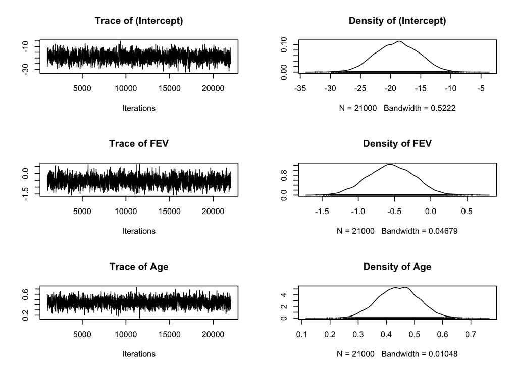

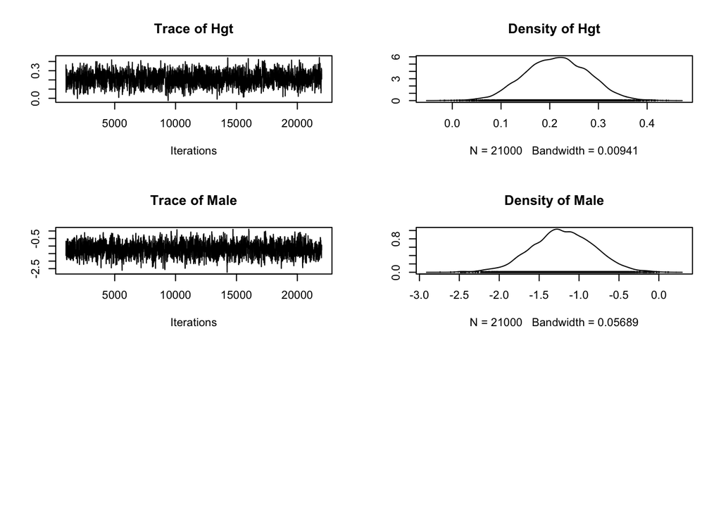

```r
out <- MCMClogit(Smoke ~ FEV + Age + Hgt + Male, burnin = 1000, mcmc = 21000)

plot(out)
```

```r
summary(out)
```

```
##
## Iterations = 1001:22000
## Thinning interval = 1
## Number of chains = 1
## Sample size per chain = 21000
##
## 1. Empirical mean and standard deviation for each variable,
##    plus standard error of the mean:
##
##                 Mean      SD  Naive SE Time-series SE
## (Intercept) -18.9097 3.60585 0.0248827       0.100986
## FEV          -0.5480 0.32310 0.0022296       0.009395
## Age           0.4431 0.07233 0.0004991       0.002071
## Hgt           0.2142 0.06497 0.0004483       0.001807
## Male         -1.2033 0.39514 0.0027268       0.011077
##
## 2. Quantiles for each variable:
##
##                  2.5%      25%      50%      75%    97.5%
## (Intercept) -25.94093 -21.3887 -18.8646 -16.4249 -12.0038
## FEV          -1.18420  -0.7685  -0.5501  -0.3264   0.0795
## Age           0.30353   0.3938   0.4430   0.4916   0.5854
## Hgt           0.09156   0.1692   0.2145   0.2601   0.3402
## Male         -1.99992  -1.4624  -1.2089  -0.9360  -0.4333
```

**Male** and **FEV** have a negative correlation with the predicted variable. **Age** has a big influence in the model

We will once again predict the probability that a person smokes given the next values: 2.4 of **FEV**, 11 will be the **Age**, 50 is the **Height** and 0.5 is **Male**. We will compute the *mean*, *median* and *credible intervals* for it.

```r
library(boot)
preds.bayes <- inv.logit(out[,1] + 2.4*out[,2] + 11*out[,3] + 50*out[,4] + 0.5*out[,5])
mean(preds.bayes)
```

```
## [1] 0.00767615
```

```r
median(preds.bayes)
```

```
## [1] 0.005359979
```

```r
quantile(preds.bayes,c(0.025,0.975))
```

```
##        2.5%       97.5%
## 0.000929616 0.028672331
```

We will create a **data.frame** to store the probabilities. The rows will have different values from the *min* to the *max* of the values of each category. (This is just an approximation and is not a greedy search algorithm that finds the best values). It is rather a mere way to visualize the probability that our model has certain values for all the parameters.

```r
predict.df <- data.frame(FEV = seq(0.5, 6, length.out = 40) , Age = seq(3, 19, length.out = 40),
                         Hgt = seq(46, 75, length.out = 40), Male = sample(0:1, 40, replace = TRUE))
predict.df['pred'] <- NA
head(predict.df)
```

```
##         FEV      Age      Hgt Male pred
## 1 0.5000000 3.000000 46.00000    1   NA
## 2 0.6410256 3.410256 46.74359    0   NA
## 3 0.7820513 3.820513 47.48718    0   NA
## 4 0.9230769 4.230769 48.23077    0   NA
## 5 1.0641026 4.641026 48.97436    0   NA
## 6 1.2051282 5.051282 49.71795    0   NA
```

```r
for (val in 1:length(predict.df[, 1])){
  predict.df[val, 5] =  mean(inv.logit(out[,1] + predict.df[val, 1]*out[,2] +
                                         predict.df[val, 2]*out[,3] +
                                         predict.df[val, 3]*out[,4] +
                                         predict.df[val, 4]*out[,5]))
}

head(predict.df)
```

```
##         FEV      Age      Hgt Male         pred
## 1 0.5000000 3.000000 46.00000    1 0.0001799892
## 2 0.6410256 3.410256 46.74359    0 0.0006289503
## 3 0.7820513 3.820513 47.48718    0 0.0007966508
## 4 0.9230769 4.230769 48.23077    0 0.0010102361
## 5 1.0641026 4.641026 48.97436    0 0.0012825664
## 6 1.2051282 5.051282 49.71795    0 0.0016301821
```

```r
tail(predict.df)
```

```
##         FEV      Age      Hgt Male      pred
## 35 5.294872 16.94872 71.28205    0 0.7107734
## 36 5.435897 17.35897 72.02564    0 0.7574017
## 37 5.576923 17.76923 72.76923    1 0.5692632
## 38 5.717949 18.17949 73.51282    0 0.8337036
## 39 5.858974 18.58974 74.25641    0 0.8637565
## 40 6.000000 19.00000 75.00000    1 0.7338733
```

```r
predict.df[which.max(predict.df[, 5]), ]
```

```
##         FEV      Age      Hgt Male      pred
## 39 5.858974 18.58974 74.25641    0 0.8637565
```

Now its tike to look at the *autocorrelation plots*.

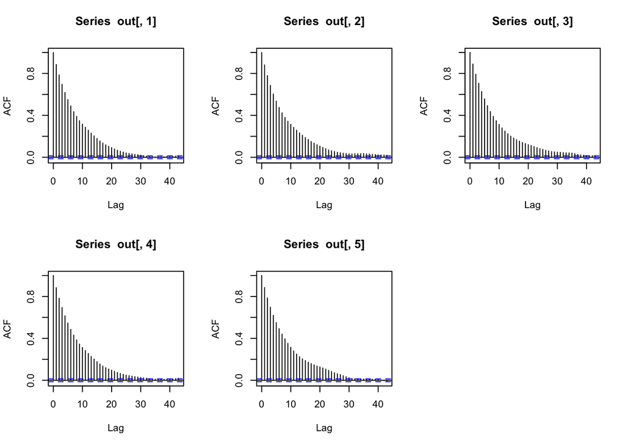

```r
par(mfrow = c(2, 3))

acf(out[,1]) # intercept
acf(out[,2]) # FEV
acf(out[,3]) # Age
acf(out[,4]) # Hgt
acf(out[,5]) # Male
```

As we can see, they present clear autocorrelation, which can be dealt with using the MCMC package.

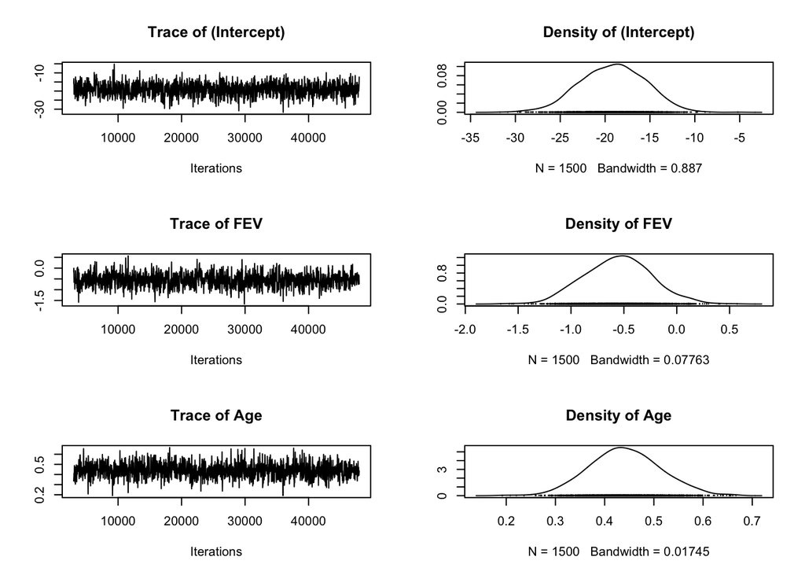

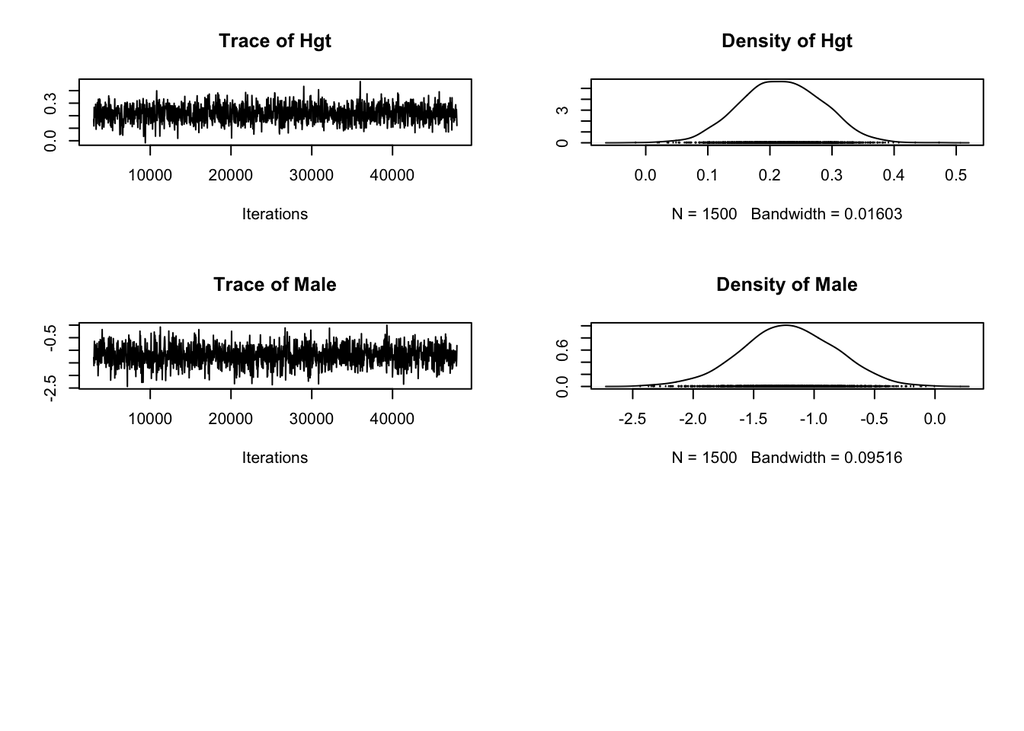

```r
new.model <- MCMClogit(Smoke ~ FEV + Age + Hgt + Male, burnin=3000, mcmc=45000, thin=30, data=data)
plot(new.model)
```

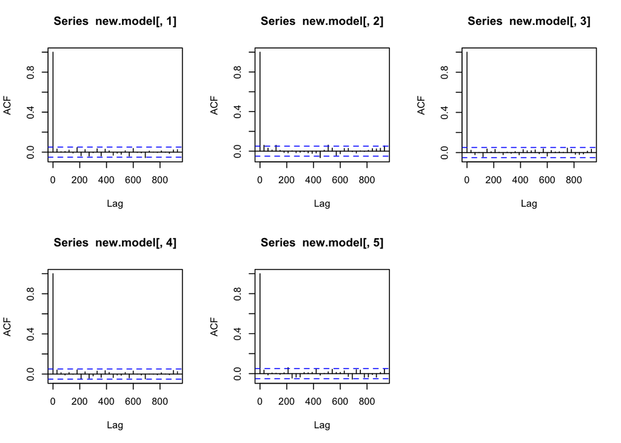

```r
# once we have a good mixin, we can take a look at the autocorrelations.

par(mfrow = c(2, 3))
acf(new.model[, 1])
acf(new.model[, 2])
acf(new.model[, 3])
acf(new.model[, 4])
acf(new.model[, 5])
```

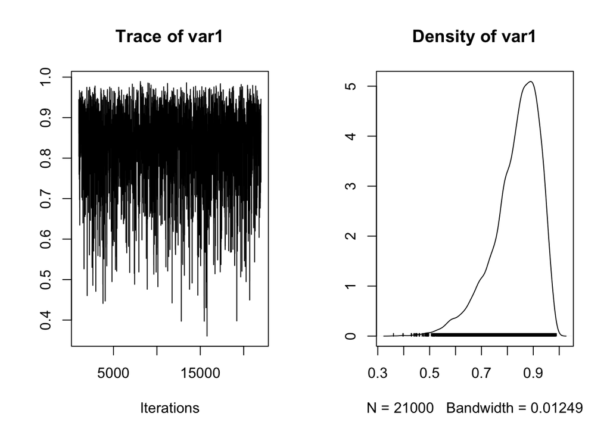

```r
library(boot)
fail.prob <- inv.logit(out[,1] + 5.72*out[,2] + 18.2*out[,3] + 73.5*out[,4] + 0*out[,5])

plot(fail.prob)
```

We get great results!

All in all, this project has allowed me to fully grasp the capabilities of the **Bayesian Analysis**and the potential it has to be useful in my coming years as a student/developer. Thanks to its ease of use, and the capabilities of $R$, it is a tool that will for sure be considered. This **Bayesian** approach, coupled with the **Frequentist** approach we saw in this course and previous ones, has allowed me to understand the field of *Statistics* a little bit more. With this project, and this class in general, my knowledge of that topic has thoroughly increased. I have also learnt new skills I did not possess before, like using *RMarkDown*, which I had not used up to this point.